# Pratical Machine Learning - Course Project

## Introduction

Using devices such as Jawbone Up, Nike FuelBand, and Fitbit it is now possible to collect a large amount of data about personal activity. One thing that people regularly do is quantify how much of a particular activity they do, but they rarely quantify how well they do it.

In this [project](https://www.coursera.org/learn/practical-machine-learning/supplement/PvInj/course-project-instructions-read-first), the goal is creating a model to predict the manner in which they did the exercise. To do so, we are going to use the data from the study about [Qualitative Activity Recognition of Weight Lifting Exercises](http://groupware.les.inf.puc-rio.br/public/papers/2013.Velloso.QAR-WLE.pdf) [1] that register the accelerometers on the belt, forearm, arm, and dumbell of 6 participants. In this study, the participants were asked to perform barbell lifts correctly and incorrectly in 5 different ways. More information about this data is available on and more details about it can be access by this website http://groupware.les.inf.puc-rio.br/har, in the section on the Weight Lifting Exercise Dataset.

## Assignment

```r
options(scipen=999)         # make the number printer more readable
Sys.setenv(LANG = "en")     # show messages on english
Sys.setenv(LANGUAGE = "en") # show messages on english
rm(list=ls())               # remove other data from env, if any
set.seed(123)               # set a seed to ensure get always the same results
```

## Data

```r
trainDataLink <- 'https://d396qusza40orc.cloudfront.net/predmachlearn/pml-training.csv'
trainDataFile <- 'pml-training.csv';
testDataLink  <- 'https://d396qusza40orc.cloudfront.net/predmachlearn/pml-testing.csv'
testDataFile  <- 'pml-testing';
```

The data for this assignment is divided among [trainng data](https://d396qusza40orc.cloudfront.net/predmachlearn/pml-training.csv) and [test data](https://d396qusza40orc.cloudfront.net/predmachlearn/pml-testing.csv):

## Loading Libraries

```r
# loading required libraries
# install.packages(c("knitr","ggplot2","data.table","caret","caretEnsemble",
#   "doParallel","e1071","rpart","rpart.plot","rattle","gridExtra"), dependencies = TRUE)
library('knitr')
library('ggplot2')
library('data.table')
library('caret')
library('devtools')
library('doParallel')
library('e1071')
library('rattle')
library('rpart')
library('rpart.plot')
library('gridExtra')
library('ggplotify')
library('cowplot')
library('kableExtra')
library('ggRandomForests')
registerDoParallel(cores=4)
```

## Loading and preprocessing the data

Download the data and load it into data.table.

```r
if ( !file.exists(trainDataFile) ) {
  download.file(trainDataLink, trainDataFile)
}
if ( !file.exists(testDataFile) ) {
  download.file(testDataLink, testDataFile)
}
trainData <- read.csv( trainDataFile, na.strings=c('#DIV/0!', '', 'NA'), stringsAsFactors = FALSE)
testData  <- read.csv( testDataFile,  na.strings=c('#DIV/0!', '', 'NA'), stringsAsFactors = FALSE)
```

### Removing Null Columns

Remove all columns with 97% or more rows with null values.

```r
MAX_PERCENT_OF_NA_VALUES = 0.97
fields <- names(trainData)
size <-nrow(trainData)
fieldsToRemove <- c()

for(field in fields) {
  column <- trainData[[field]]
  percentOfNA <- ( (length(column[is.na(column)])) / size )
  if( percentOfNA >= MAX_PERCENT_OF_NA_VALUES ) {
    fieldsToRemove[length(fieldsToRemove)+1] <- field;
  }
}
print(paste("removing these fields for having to many empty values: (",paste(fieldsToRemove, collapse = ', '),")"));
```

[output not shown]

```r
# using the same field list to train and test to avoid different field list
trainData <- trainData[ , !(colnames(trainData) %in% fieldsToRemove)]
testData  <- testData[  , !(colnames(testData)  %in% fieldsToRemove)]
```

### Replacing Null values by the Median

Replace remaing null values by the median or the most common value.

```r
fields <- names(trainData)
commonValues <- c()
for(field in fields) {
  column <- trainData[[field]]
  if(!is.character(column)){
    new_value <- median(column)
  } else {
    new_value <- names(sort(table(column),decreasing=TRUE)[1])
  }
  commonValues[field] <- new_value;
}
replaceNullByCommonValues <- function(dataframe,commonValues) {
  for(field in fields) {
    column <- dataframe[[field]]
    totalNull <- length(column[is.na(column)])
    if(totalNull > 0) {
      commonValue <- commonValues[field]
      print(paste("replacing",totalNull," null values on",field,"by",commonValue))
      column[is.na(column)] <- commonValue
      dataframe[[field]] <- column
    }
  }
  return(dataframe)
}
trainData <- replaceNullByCommonValues(trainData,commonValues)
testData  <- replaceNullByCommonValues(testData,commonValues)
print("all the null values where replaced by the common values")
```

```
## [1] "all the null values where replaced by the common values"
```

## Remove Near Zero Variance Columns

```r
nearZeroVarFields <- nearZeroVar(trainData, names = TRUE)
trainData <- trainData[ , !(colnames(trainData) %in% nearZeroVarFields)]
if( length(nearZeroVarFields) > 0 ) {
  cat(paste("removing these fields for having near zero variance: (",paste(nearZeroVarFields, collapse = ', '),")"));
} else {
  cat("all fields have a acceptable variance")
}
```

```
## removing these fields for having near zero variance: ( new_window )
```

## Remove Id and Time columns

The goal is detect if the exercise is being done correctly or not based on the detected device data. In this goal, when the data was collected or who is the user should not affect the result.

```r
fieldsToRemove <- c("X", "user_name", "raw_timestamp_part_1", "raw_timestamp_part_2", "cvtd_timestamp", "new_window", "num_window")
trainData <- trainData[ , !(colnames(trainData) %in% fieldsToRemove)]
cat("id columns removed")
```

```
## id columns removed
```

## Separate Validation Data

```r
set.seed(123)
targetFields <- c("classe")

trainDataRows               <- createDataPartition(y = trainData$classe, p = 0.9, list = FALSE)

trainDataset                <- trainData[ trainDataRows,]
trainDatasetPredictors      <- trainData[ trainDataRows, !(colnames(trainData) %in% targetFields)]
trainDatasetTarget          <- factor(trainData[ trainDataRows, ]$classe)

validationDataset           <- trainData[-trainDataRows,]
validationDatasetPredictors <- trainData[-trainDataRows, !(colnames(trainData) %in% targetFields)]
validationDatasetTarget     <- factor(trainData[-trainDataRows, ]$classe)

cat(paste("train dataset have ",nrow(trainDataset),"rows"),"\n")
```

```
## train dataset have  17662 rows
```

```r
cat(paste("validation dataset have ",nrow(validationDataset),"rows"),"\n")
```

```
## validation dataset have  1960 rows
```

```r
cat(paste("test dataset have ",nrow(testData),"rows"),"\n")
```

```
## test dataset have  20 rows
```

## Creating Models

```r
set.seed(123)
folds = 3
modelTrainControl <- trainControl(
  method = "cv",             # for “cross-validation”
  number = folds,            # number of k-folds
  returnResamp = 'final',
  classProb = TRUE,
  returnData = FALSE,
  savePredictions = FALSE,
  verboseIter = TRUE,
  allowParallel = TRUE,
  index=createFolds(trainDataset$classe,k=folds)
)

preProcess=c("pca","center","scale")
modelFitBag                  <- train(classe ~ ., data = trainDataset, method = "treebag",
                                      preProcess = preProcess, trControl=modelTrainControl)
modelKNearestNeighbor        <- train(classe ~ ., data = trainDataset, method = "knn",
                                      preProcess = preProcess, trControl=modelTrainControl)
modelRecursivePartition      <- train(classe ~ ., data = trainDataset, method = "rpart",
                                      preProcess = preProcess, trControl=modelTrainControl)
modelGradientBoostingMachine <- train(classe ~ ., data = trainDataset, method = "gbm",
                                      preProcess = preProcess, trControl=modelTrainControl)
modelRandomForest            <- train(classe ~ ., data = trainDataset, method = "rf",
                                      preProcess = preProcess, trControl=modelTrainControl)
allModels <- list(
  modelFitBag,
  modelKNearestNeighbor,
  modelRecursivePartition,
  modelGradientBoostingMachine,
  modelRandomForest
)
names(allModels) <- sapply(allModels, function(x) x$method)
sort(sapply(allModels, function(x) x$results$Accuracy[length(x$results$Accuracy)]),decreasing = TRUE)
```

```
##        rf   treebag       knn       gbm     rpart
## 0.9290286 0.9141377 0.8611988 0.8066752 0.2843393
```

```r
summaryModels <- resamples(
  list(
    fitBag=modelFitBag,
    knm=modelKNearestNeighbor,
    rpart=modelRecursivePartition,
    gbm=modelGradientBoostingMachine,
    rf=modelRandomForest
  )
)
summary(summaryModels)
```

```
##
## Call:
## summary.resamples(object = summaryModels)
##
## Models: fitBag, knm, rpart, gbm, rf
## Number of resamples: 3
##
## Accuracy
##             Min.   1st Qu.    Median      Mean   3rd Qu.      Max. NA's
## fitBag 0.9061491 0.9098511 0.9135530 0.9141377 0.9181320 0.9227111    0
## knm    0.8838967 0.8928655 0.9018342 0.8958778 0.9018684 0.9019025    0
## rpart  0.3357398 0.3670886 0.3984375 0.3784101 0.3997453 0.4010532    0
## gbm    0.7999830 0.8044158 0.8088485 0.8066752 0.8100213 0.8111942    0
## rf     0.9327331 0.9391077 0.9454823 0.9421355 0.9468366 0.9481909    0
##
## Kappa
##             Min.   1st Qu.    Median      Mean   3rd Qu.      Max. NA's
## fitBag 0.8812924 0.8859546 0.8906168 0.8913622 0.8963971 0.9021774    0
## knm    0.8531573 0.8644671 0.8757769 0.8682613 0.8758133 0.8758498    0
## rpart  0.1415161 0.1772751 0.2130341 0.1907712 0.2153988 0.2177635    0
## gbm    0.7466467 0.7521686 0.7576904 0.7550530 0.7592561 0.7608218    0
## rf     0.9148974 0.9229492 0.9310009 0.9267757 0.9327148 0.9344288    0
```

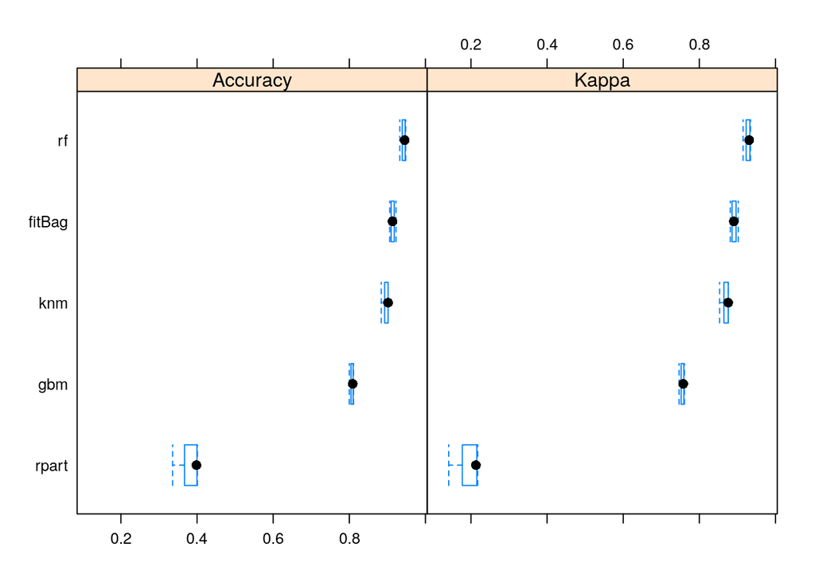

```r
bwplot(summaryModels)
```

## Confusion Matrix for each Model

```r
getAccuracy <- function(model) {
  return(model$result$Accuracy[length(model$result$Accuracy)])
}

allModels.prediction <- list()
allModels.accuracy <- list()
allModels.plot <- list()
test <- ggplot(mtcars, aes(mpg, hp)) + geom_point()

setNumberPrecision <- function(x, k) trimws(format(round(x, k), nsmall=k))

printConfusion <- function(currentConfusionMatrix, modelName) {
  confusionMatrixAsDataFrame <- data.frame(currentConfusionMatrix$table)
  confmatrix_df <- data.frame(currentConfusionMatrix$table)
  plotConfSquares <- ggplot(confmatrix_df) + geom_tile(aes(x=Prediction, y=Reference, fill=Freq))

  cat("### Model ",modelName,"\n")

  currentModel <- allModels[modelName]

  label <- paste('Confusion Matrix of model',modelName)
  cat(paste0("#### ",label,"\n\n"))
  cat(paste0(kable(currentConfusionMatrix$table,digits = 4) %>%
    kable_styling(bootstrap_options = "striped", full_width = F, position = "center"),collapse="\n"))
  cat('\n\n')

  cat('\n')
  cat("#### Overall Statistics\n\n")
  cat('\n')

  numberDigits <- 4
  tableColumns <- c("Accuracy","95% CI","No Information Rate","Kappa","Mcnemar's Test P-Value")
  tableValues <- c(
    setNumberPrecision(currentConfusionMatrix$overall[["Accuracy"]], numberDigits),       # Accuracy
    paste0(                                                                               # Confidence Interval of accuracy
      "(",
      setNumberPrecision(currentConfusionMatrix$overall[["AccuracyLower"]], numberDigits),
      ",",
      setNumberPrecision(currentConfusionMatrix$overall[["AccuracyUpper"]], numberDigits),
      ")"
    ),
    setNumberPrecision(currentConfusionMatrix$overall[["AccuracyPValue"]], numberDigits), # no information rate
    setNumberPrecision(currentConfusionMatrix$overall[["Kappa"]], numberDigits),          # kappa
    setNumberPrecision(currentConfusionMatrix$overall[["McnemarPValue"]], numberDigits)   # Mcnemar's Test P-Value
  )
  tableStatistics <- data.frame(statistics = tableColumns, values = tableValues)
  cat(paste0(kable(tableStatistics,digits = 4) %>%
    kable_styling(bootstrap_options = "striped", full_width = F, position = "center"),collapse="\n"))
  cat('\n\n')

  label <- paste('Statistics by Class of model',modelName)
  cat('\n')
  cat(paste0("#### ",label,"\n\n"))
  cat(paste0(knitr::kable(currentConfusionMatrix$byClass,digits = 4) %>%
    kable_styling(bootstrap_options = "striped", full_width = F, position = "left", font_size = 11),collapse="\n"))
  cat('\n\n')

  print(plotConfSquares)
  cat('\n\n')
  if(modelName=="rpart"){
    fancyRpartPlot(currentModel$rpart$finalModel)
  }
  if(modelName=="rf"){
    randomForestError <- gg_error(currentModel$rf$finalModel)
    print(plot(randomForestError))
  }
  cat('\n\n')
}

for(modelName in names(allModels)) {
  set.seed(123)
  currentModel <- allModels[modelName]
  predictedClasse <- predict(currentModel,validationDataset)
  allModels.prediction[[modelName]] <- predictedClasse
  allModels.accuracy[[modelName]] <- getAccuracy(currentModel[[modelName]])

  currentConfusionMatrix <- confusionMatrix(predictedClasse[[modelName]], as.factor(validationDataset$classe))
  printConfusion(currentConfusionMatrix, modelName)
}
```

### Model treebag

#### Confusion Matrix of model treebag

|  | A | B | C | D | E |
| --- | --- | --- | --- | --- | --- |
| A | 551 | 7 | 1 | 1 | 1 |
| B | 2 | 367 | 3 | 0 | 6 |
| C | 0 | 2 | 334 | 11 | 6 |
| D | 4 | 1 | 4 | 307 | 3 |
| E | 1 | 2 | 0 | 2 | 344 |

#### Overall Statistics

[output not shown]

#### Statistics by Class of model treebag

|  | Sensitivity | Specificity | Pos Pred Value | Neg Pred Value | Precision | Recall | F1 | Prevalence | Detection Rate | Detection Prevalence | Balanced Accuracy |
| --- | --- | --- | --- | --- | --- | --- | --- | --- | --- | --- | --- |
| Class: A | 0.9875 | 0.9929 | 0.9822 | 0.9950 | 0.9822 | 0.9875 | 0.9848 | 0.2847 | 0.2811 | 0.2862 | 0.9902 |
| Class: B | 0.9683 | 0.9930 | 0.9709 | 0.9924 | 0.9709 | 0.9683 | 0.9696 | 0.1934 | 0.1872 | 0.1929 | 0.9807 |
| Class: C | 0.9766 | 0.9883 | 0.9462 | 0.9950 | 0.9462 | 0.9766 | 0.9612 | 0.1745 | 0.1704 | 0.1801 | 0.9824 |
| Class: D | 0.9564 | 0.9927 | 0.9624 | 0.9915 | 0.9624 | 0.9564 | 0.9594 | 0.1638 | 0.1566 | 0.1628 | 0.9745 |
| Class: E | 0.9556 | 0.9969 | 0.9857 | 0.9901 | 0.9857 | 0.9556 | 0.9704 | 0.1837 | 0.1755 | 0.1781 | 0.9762 |

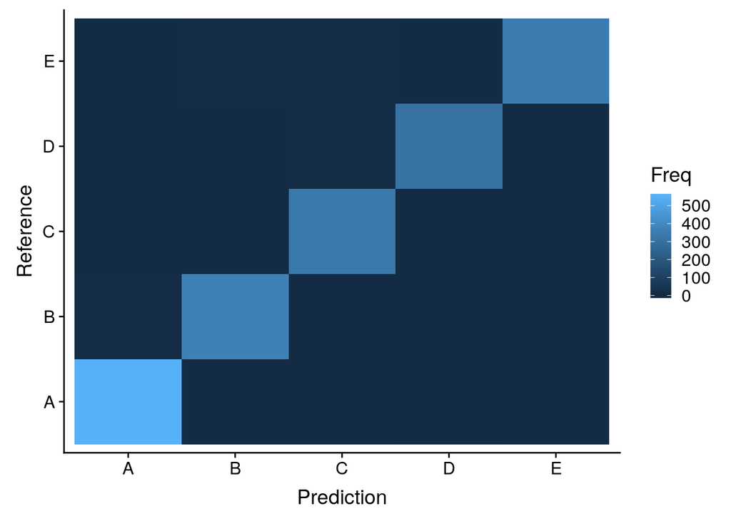

### Model knn

#### Confusion Matrix of model knn

|  | A | B | C | D | E |
| --- | --- | --- | --- | --- | --- |
| A | 550 | 8 | 0 | 1 | 1 |
| B | 2 | 363 | 1 | 0 | 1 |
| C | 2 | 7 | 338 | 11 | 5 |
| D | 3 | 0 | 3 | 307 | 2 |
| E | 1 | 1 | 0 | 2 | 351 |

#### Overall Statistics

[output not shown]

#### Statistics by Class of model knn

|  | Sensitivity | Specificity | Pos Pred Value | Neg Pred Value | Precision | Recall | F1 | Prevalence | Detection Rate | Detection Prevalence | Balanced Accuracy |
| --- | --- | --- | --- | --- | --- | --- | --- | --- | --- | --- | --- |
| Class: A | 0.9857 | 0.9929 | 0.9821 | 0.9943 | 0.9821 | 0.9857 | 0.9839 | 0.2847 | 0.2806 | 0.2857 | 0.9893 |
| Class: B | 0.9578 | 0.9975 | 0.9891 | 0.9900 | 0.9891 | 0.9578 | 0.9732 | 0.1934 | 0.1852 | 0.1872 | 0.9776 |
| Class: C | 0.9883 | 0.9845 | 0.9311 | 0.9975 | 0.9311 | 0.9883 | 0.9589 | 0.1745 | 0.1724 | 0.1852 | 0.9864 |
| Class: D | 0.9564 | 0.9951 | 0.9746 | 0.9915 | 0.9746 | 0.9564 | 0.9654 | 0.1638 | 0.1566 | 0.1607 | 0.9758 |
| Class: E | 0.9750 | 0.9975 | 0.9887 | 0.9944 | 0.9887 | 0.9750 | 0.9818 | 0.1837 | 0.1791 | 0.1811 | 0.9862 |

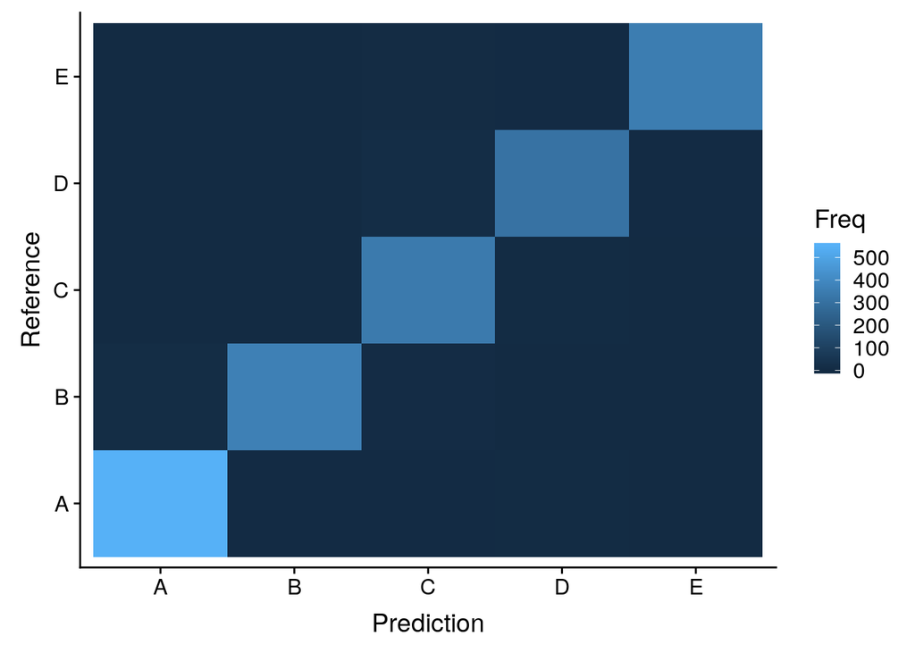

### Model rpart

#### Confusion Matrix of model rpart

|  | A | B | C | D | E |
| --- | --- | --- | --- | --- | --- |
| A | 507 | 221 | 318 | 154 | 147 |
| B | 0 | 0 | 0 | 0 | 0 |
| C | 0 | 0 | 0 | 0 | 0 |
| D | 40 | 76 | 17 | 123 | 56 |
| E | 11 | 82 | 7 | 44 | 157 |

#### Overall Statistics

[output not shown]

#### Statistics by Class of model rpart

|  | Sensitivity | Specificity | Pos Pred Value | Neg Pred Value | Precision | Recall | F1 | Prevalence | Detection Rate | Detection Prevalence | Balanced Accuracy |
| --- | --- | --- | --- | --- | --- | --- | --- | --- | --- | --- | --- |
| Class: A | 0.9086 | 0.4009 | 0.3764 | 0.9168 | 0.3764 | 0.9086 | 0.5323 | 0.2847 | 0.2587 | 0.6872 | 0.6547 |
| Class: B | 0.0000 | 1.0000 | NaN | 0.8066 | NA | 0.0000 | NA | 0.1934 | 0.0000 | 0.0000 | 0.5000 |
| Class: C | 0.0000 | 1.0000 | NaN | 0.8255 | NA | 0.0000 | NA | 0.1745 | 0.0000 | 0.0000 | 0.5000 |
| Class: D | 0.3832 | 0.8847 | 0.3942 | 0.8799 | 0.3942 | 0.3832 | 0.3886 | 0.1638 | 0.0628 | 0.1592 | 0.6339 |
| Class: E | 0.4361 | 0.9100 | 0.5216 | 0.8776 | 0.5216 | 0.4361 | 0.4750 | 0.1837 | 0.0801 | 0.1536 | 0.6731 |

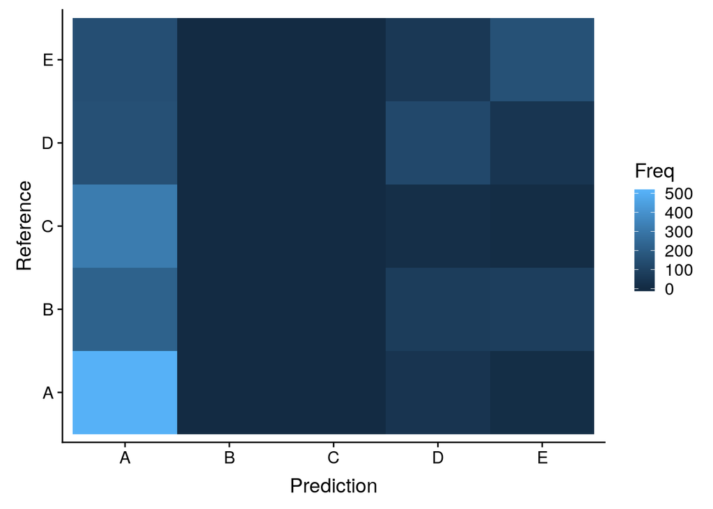

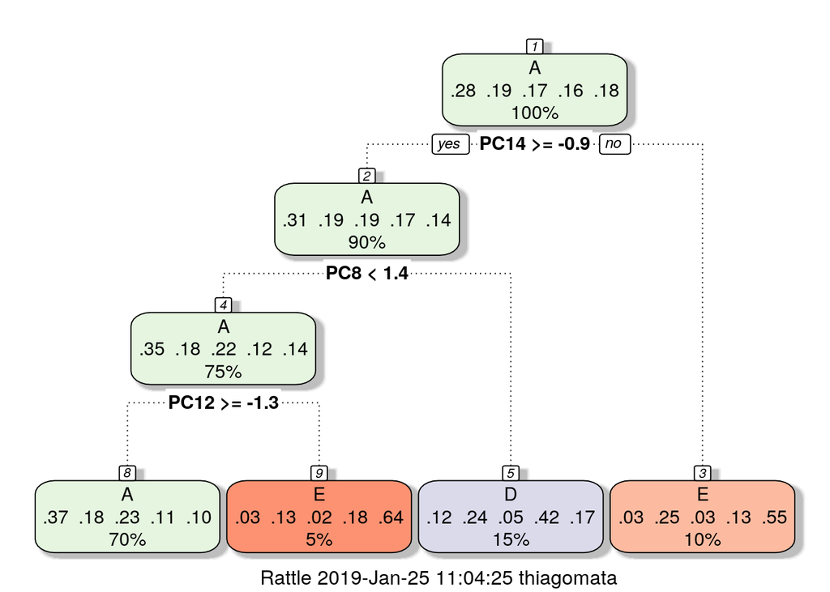

### Model gbm

#### Confusion Matrix of model gbm

|  | A | B | C | D | E |
| --- | --- | --- | --- | --- | --- |
| A | 502 | 32 | 21 | 11 | 6 |
| B | 11 | 302 | 26 | 4 | 28 |
| C | 20 | 29 | 279 | 36 | 25 |
| D | 20 | 6 | 9 | 264 | 17 |
| E | 5 | 10 | 7 | 6 | 284 |

#### Overall Statistics

[output not shown]

#### Statistics by Class of model gbm

|  | Sensitivity | Specificity | Pos Pred Value | Neg Pred Value | Precision | Recall | F1 | Prevalence | Detection Rate | Detection Prevalence | Balanced Accuracy |
| --- | --- | --- | --- | --- | --- | --- | --- | --- | --- | --- | --- |
| Class: A | 0.8996 | 0.9501 | 0.8776 | 0.9597 | 0.8776 | 0.8996 | 0.8885 | 0.2847 | 0.2561 | 0.2918 | 0.9249 |
| Class: B | 0.7968 | 0.9564 | 0.8140 | 0.9515 | 0.8140 | 0.7968 | 0.8053 | 0.1934 | 0.1541 | 0.1893 | 0.8766 |
| Class: C | 0.8158 | 0.9320 | 0.7172 | 0.9599 | 0.7172 | 0.8158 | 0.7633 | 0.1745 | 0.1423 | 0.1985 | 0.8739 |
| Class: D | 0.8224 | 0.9683 | 0.8354 | 0.9653 | 0.8354 | 0.8224 | 0.8289 | 0.1638 | 0.1347 | 0.1612 | 0.8954 |
| Class: E | 0.7889 | 0.9825 | 0.9103 | 0.9539 | 0.9103 | 0.7889 | 0.8452 | 0.1837 | 0.1449 | 0.1592 | 0.8857 |

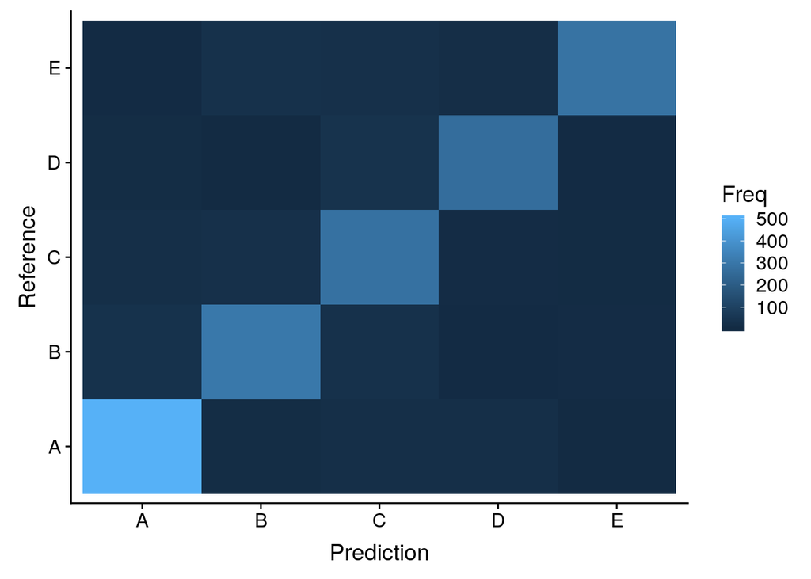

### Model rf

#### Confusion Matrix of model rf

|  | A | B | C | D | E |
| --- | --- | --- | --- | --- | --- |
| A | 557 | 7 | 0 | 0 | 0 |
| B | 0 | 370 | 1 | 0 | 1 |
| C | 0 | 2 | 340 | 11 | 2 |
| D | 1 | 0 | 1 | 309 | 1 |
| E | 0 | 0 | 0 | 1 | 356 |

#### Overall Statistics

[output not shown]

#### Statistics by Class of model rf

|  | Sensitivity | Specificity | Pos Pred Value | Neg Pred Value | Precision | Recall | F1 | Prevalence | Detection Rate | Detection Prevalence | Balanced Accuracy |
| --- | --- | --- | --- | --- | --- | --- | --- | --- | --- | --- | --- |
| Class: A | 0.9982 | 0.9950 | 0.9876 | 0.9993 | 0.9876 | 0.9982 | 0.9929 | 0.2847 | 0.2842 | 0.2878 | 0.9966 |
| Class: B | 0.9763 | 0.9987 | 0.9946 | 0.9943 | 0.9946 | 0.9763 | 0.9854 | 0.1934 | 0.1888 | 0.1898 | 0.9875 |
| Class: C | 0.9942 | 0.9907 | 0.9577 | 0.9988 | 0.9577 | 0.9942 | 0.9756 | 0.1745 | 0.1735 | 0.1811 | 0.9924 |
| Class: D | 0.9626 | 0.9982 | 0.9904 | 0.9927 | 0.9904 | 0.9626 | 0.9763 | 0.1638 | 0.1577 | 0.1592 | 0.9804 |
| Class: E | 0.9889 | 0.9994 | 0.9972 | 0.9975 | 0.9972 | 0.9889 | 0.9930 | 0.1837 | 0.1816 | 0.1821 | 0.9941 |

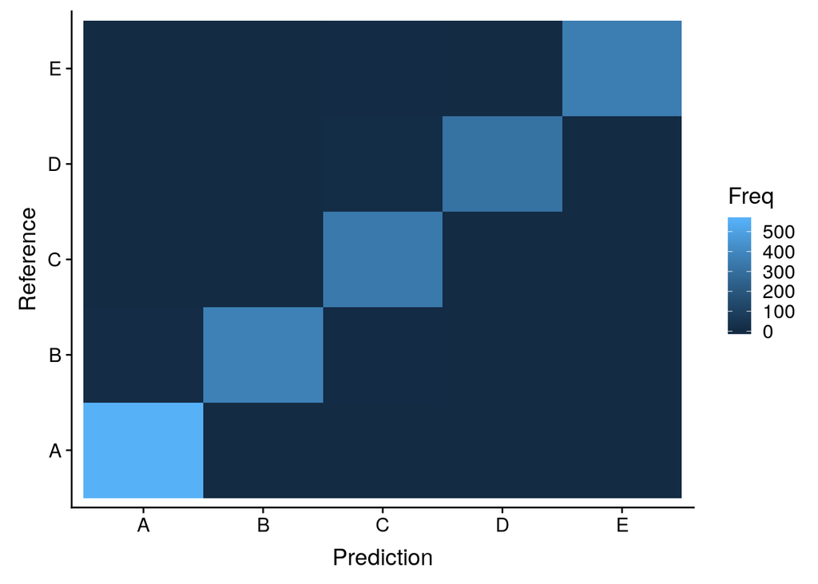

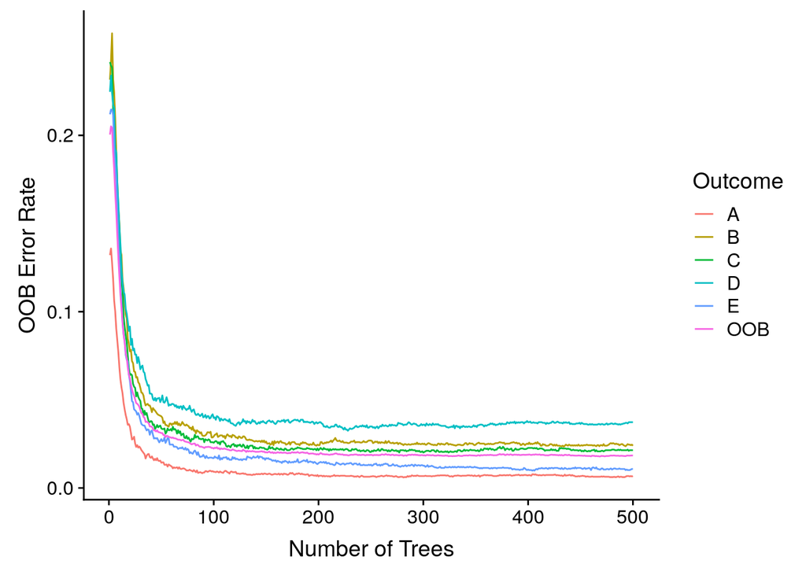

## Voting Mechanism

```r
getVotingScore <- function(predictions,value) {
    return(
      ifelse(predictions$predFitBag                     == value, predictions$accuracyFitBag, 0) +
      ifelse(predictions$predictKNearesNeighbor         == value, predictions$accuracyKNearesNeighbor, 0) +
      ifelse(predictions$predictRecursivePartition      == value, predictions$accuracyRecursivePartition, 0) +
      ifelse(predictions$predictGradientBoostingMachine == value, predictions$accuracyGradientBoostingMachine, 0) +
      ifelse(predictions$predictRandomForest            == value, predictions$accuracyRandomForest, 0) +
      0
    )
}

voting <- function(data) {

  # Any model with worse accuracy than this, should not be considered on the voting ( score = 0 )
  MIN_ACCURACY = 0.8

  # FIT BAG
  predFitBag                      <- predict(modelFitBag, data)
  accuracyFitBag                  <- ifelse(getAccuracy(modelFitBag) > MIN_ACCURACY,getAccuracy(modelGradientBoostingMachine),0)
  # GRADIENT BOOSTING MACHINE
  predictGradientBoostingMachine  <- predict(modelGradientBoostingMachine, data)
  accuracyGradientBoostingMachine <- ifelse(getAccuracy(modelGradientBoostingMachine) > MIN_ACCURACY,getAccuracy(modelGradientBoostingMachine),0)
  # K NEARES NEIGHBOR
  predictKNearesNeighbor          <- predict(modelKNearestNeighbor, data)
  accuracyKNearesNeighbor         <- ifelse(getAccuracy(modelKNearestNeighbor) > MIN_ACCURACY,getAccuracy(modelKNearestNeighbor),0)
  # RECURSIVE PARTITION
  predictRecursivePartition       <- predict(modelRecursivePartition, data)
  accuracyRecursivePartition      <- ifelse(getAccuracy(modelRecursivePartition) > MIN_ACCURACY,getAccuracy(modelRecursivePartition),0)
  # RANDOM FOREST
  predictRandomForest             <- predict(modelRandomForest, data)
  accuracyRandomForest            <- ifelse(getAccuracy(modelRandomForest) > MIN_ACCURACY,getAccuracy(modelRandomForest),0)

  sumAccuracy <-
    accuracyFitBag +
    accuracyGradientBoostingMachine +
    accuracyKNearesNeighbor +
    accuracyRecursivePartition +
    accuracyRandomForest +
    0

  predictions <- data.frame(
    predFitBag,
    accuracyFitBag,
    predictKNearesNeighbor,
    accuracyKNearesNeighbor,
    predictRecursivePartition,
    accuracyRecursivePartition,
    predictGradientBoostingMachine,
    accuracyGradientBoostingMachine,
    predictRandomForest,
    accuracyRandomForest
  )
  scoreA <-getVotingScore(predictions,'A') / sumAccuracy
  scoreB <-getVotingScore(predictions,'B') / sumAccuracy
  scoreC <-getVotingScore(predictions,'C') / sumAccuracy
  scoreD <-getVotingScore(predictions,'D') / sumAccuracy
  scoreE <-getVotingScore(predictions,'E') / sumAccuracy

  votingData <- data.frame(
    scoreA,
    scoreB,
    scoreC,
    scoreD,
    scoreE
  )

  votingData[ is.na(votingData$scoreA), "scoreA" ]  <- c(0)
  votingData[ is.na(votingData$scoreB), "scoreB" ]  <- c(0)
  votingData[ is.na(votingData$scoreC), "scoreC" ]  <- c(0)
  votingData[ is.na(votingData$scoreD), "scoreD" ]  <- c(0)
  votingData[ is.na(votingData$scoreE), "scoreE" ]  <- c(0)

  votingData$maxScore <- apply(votingData,1,max)

  votingData$voted <- c()
  votingData[votingData$scoreA == votingData$maxScore, "voted"] <- 'A'
  votingData[votingData$scoreB == votingData$maxScore, "voted"] <- 'B'
  votingData[votingData$scoreC == votingData$maxScore, "voted"] <- 'C'
  votingData[votingData$scoreD == votingData$maxScore, "voted"] <- 'D'
  votingData[votingData$scoreE == votingData$maxScore, "voted"] <- 'E'
  votingData$classe <- data$classe
  return(votingData)
}
votedValidation <- voting(validationDataset)
votingConfusionMatrix <- confusionMatrix(as.factor(votedValidation$voted),as.factor(validationDataset$classe))
allModels.accuracy["voting"] <- votingConfusionMatrix$overall['Accuracy']
printConfusion(votingConfusionMatrix, "voting")
```

### Model voting

#### Confusion Matrix of model voting

|  | A | B | C | D | E |
| --- | --- | --- | --- | --- | --- |
| A | 557 | 7 | 0 | 0 | 0 |
| B | 0 | 369 | 2 | 0 | 1 |
| C | 0 | 2 | 338 | 11 | 3 |
| D | 1 | 0 | 2 | 309 | 2 |
| E | 0 | 1 | 0 | 1 | 354 |

#### Overall Statistics

[output not shown]

#### Statistics by Class of model voting

|  | Sensitivity | Specificity | Pos Pred Value | Neg Pred Value | Precision | Recall | F1 | Prevalence | Detection Rate | Detection Prevalence | Balanced Accuracy |
| --- | --- | --- | --- | --- | --- | --- | --- | --- | --- | --- | --- |
| Class: A | 0.9982 | 0.9950 | 0.9876 | 0.9993 | 0.9876 | 0.9982 | 0.9929 | 0.2847 | 0.2842 | 0.2878 | 0.9966 |
| Class: B | 0.9736 | 0.9981 | 0.9919 | 0.9937 | 0.9919 | 0.9736 | 0.9827 | 0.1934 | 0.1883 | 0.1898 | 0.9859 |
| Class: C | 0.9883 | 0.9901 | 0.9548 | 0.9975 | 0.9548 | 0.9883 | 0.9713 | 0.1745 | 0.1724 | 0.1806 | 0.9892 |
| Class: D | 0.9626 | 0.9969 | 0.9841 | 0.9927 | 0.9841 | 0.9626 | 0.9732 | 0.1638 | 0.1577 | 0.1602 | 0.9798 |
| Class: E | 0.9833 | 0.9988 | 0.9944 | 0.9963 | 0.9944 | 0.9833 | 0.9888 | 0.1837 | 0.1806 | 0.1816 | 0.9910 |

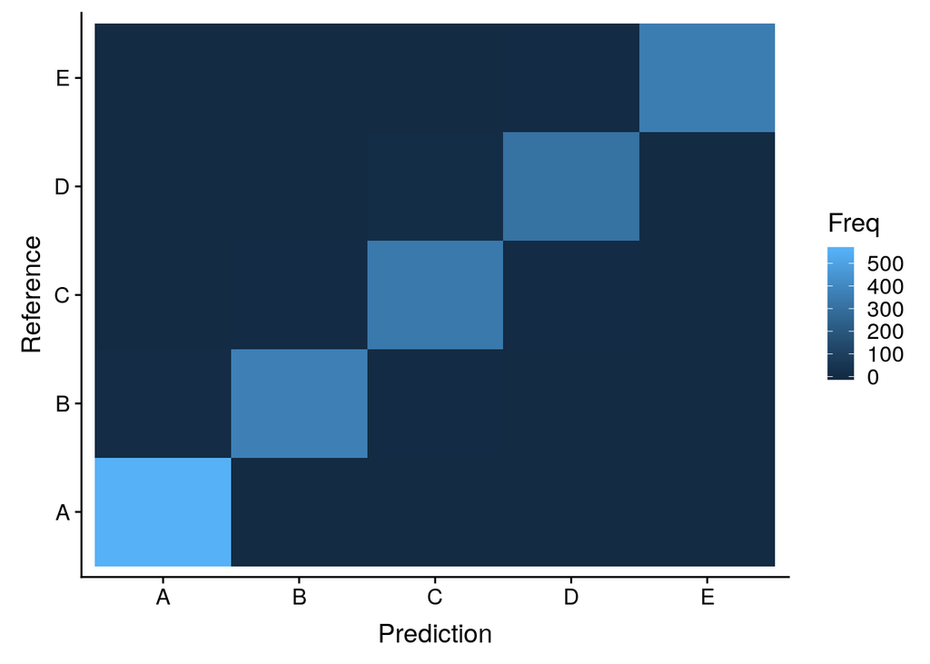

## Choosing the final Model

The voting process show a good result and because it is combining different approachs it is more hard to have the same type of overfitting.

## Show some samples of prediction on Test Data

```r
predictSamples <- voting(testData)
knitr::kable(predictSamples,caption='predicting classe of the test data based on the model',align = "c") %>%
  kable_styling(bootstrap_options = c("striped", "hover", "condensed"))
```

predicting classe of the test data based on the model

| scoreA | scoreB | scoreC | scoreD | scoreE | maxScore | voted |
| --- | --- | --- | --- | --- | --- | --- |
| 0.000000 | 0.7629920 | 0.2370080 | 0 | 0 | 0.762992 | B |
| 1.000000 | 0.0000000 | 0.0000000 | 0 | 0 | 1.000000 | A |
| 0.474016 | 0.2729565 | 0.2530275 | 0 | 0 | 0.474016 | A |
| 1.000000 | 0.0000000 | 0.0000000 | 0 | 0 | 1.000000 | A |
| 1.000000 | 0.0000000 | 0.0000000 | 0 | 0 | 1.000000 | A |
| 0.000000 | 0.0000000 | 0.0000000 | 0 | 1 | 1.000000 | E |
| 0.000000 | 0.0000000 | 0.0000000 | 1 | 0 | 1.000000 | D |
| 0.000000 | 1.0000000 | 0.0000000 | 0 | 0 | 1.000000 | B |
| 1.000000 | 0.0000000 | 0.0000000 | 0 | 0 | 1.000000 | A |
| 1.000000 | 0.0000000 | 0.0000000 | 0 | 0 | 1.000000 | A |
| 0.474016 | 0.5259840 | 0.0000000 | 0 | 0 | 0.525984 | B |
| 0.000000 | 0.0000000 | 1.0000000 | 0 | 0 | 1.000000 | C |
| 0.000000 | 1.0000000 | 0.0000000 | 0 | 0 | 1.000000 | B |
| 1.000000 | 0.0000000 | 0.0000000 | 0 | 0 | 1.000000 | A |
| 0.000000 | 0.0000000 | 0.0000000 | 0 | 1 | 1.000000 | E |
| 0.000000 | 0.0000000 | 0.0000000 | 0 | 1 | 1.000000 | E |
| 1.000000 | 0.0000000 | 0.0000000 | 0 | 0 | 1.000000 | A |
| 0.000000 | 1.0000000 | 0.0000000 | 0 | 0 | 1.000000 | B |
| 0.000000 | 1.0000000 | 0.0000000 | 0 | 0 | 1.000000 | B |
| 0.000000 | 1.0000000 | 0.0000000 | 0 | 0 | 1.000000 | B |

```r
cat(predictSamples$voted)
```

```
## B A A A A E D B A A B C B A E E A B B B
```

## Biografy

[1] Velloso, E.; Bulling, A.; Gellersen, H.; Ugulino, W.; Fuks, H. [Qualitative Activity Recognition of Weight Lifting Exercises](http://groupware.les.inf.puc-rio.br/public/papers/2013.Velloso.QAR-WLE.pdf). Proceedings of 4th International Conference in Cooperation with SIGCHI (Augmented Human ’13) . Stuttgart, Germany: ACM SIGCHI, 2013.